# General Linear Model

André Meichtry

```r
library(psych)
```

# 1 Analysis of covariance

We have looked at linear models with **categorical independent variables**, often called ANOVA. Remember though that we looked at ANOVA from a more global perspective, the perspective of model comparison.

Now, we look at a problem where we have one **continuous predictor** in addition to a categorical predictor. Such models are also called **ANCOVA or analysis of covariance**.

In our journey, an ANCOVA is (just) one further special case of the General linear Model (LM) which allows multiple categorical and continuous predictors.

## 1.1 Statistical model

Remember that a model equation includes fixed and random quantities,

$\underbrace{Y_i}_{response}=\underbrace{\mu_i}_{deterministic}+\underbrace{\epsilon_i}_{stochastic}, \quad i=1,\ldots,n.$

Assume we have

- one categorical predictor **group** with 2 values $A$ and $B$
- one **continuous** predictor $X$.
- We then need 4 (5) parameters: **intercept** and **slope** for each group plus error standard deviation.
- The **Effects parameterization** of the interaction-effects model is

$Y_i=\underbrace{\beta_1+\beta_2 I_{B(i)}+\beta_3\,x_i+\beta_4\,x_i\,I_{B(i)}}_{\mu_i}+\epsilon_i$ with indicator variable

$$I_{B(i)} =
\begin{cases}
0, & B(i)=A \\
1, & B(i)=B
\end{cases}$$

The expectations (``Long run average’’):

- $E(Y_i; group_i=A,X_i=\,0)=\beta_1$
- $E(Y_i; group_i=B,X_i=\,0)=\beta_1+\beta_2$
- $E(Y_i; group_i=A,X_i=x_i)=\beta_1+\beta_3x_i$
- $E(Y_i; group_i=B,X_i=x_i)=\beta_1+\beta_2+(\beta_3+\beta_4)x_i$

The quantity of interest are the parameters of the model, i.e. $\beta_4$, the **difference in slopes between groups**.

## 1.2 Simulation of data*

It is not mandatory to understand the data simulation code. But there is considerable conceptual value in studying the code if you have time.

```r
set.seed(10)
n.groups <- 2
n.sample <- 30
n <- n.groups*n.sample ##sample size
ind <- rep(1:n.groups, each=n.sample) ##Indicator for group
group <- factor(ind, labels = c("A", "B"))
height <- rnorm(n, mean=165, sd=11.4)
covariates<-data.frame(group,height)
Xeffects <- model.matrix(~group*height)
Xmeans <- model.matrix(~group*height-height-1)
sigma <-2
betaMeans <- c(muA<--36.475,muB<--45.5,slopeA<-0.615,slopeB<-0.7)
betaEffects <- c(muA,muB-muA,slopeA,slopeB-slopeA)
lin.pred <- Xeffects %*% betaEffects
lin.pred2 <- Xmeans %*% betaMeans
#all.equal(lin.pred,lin.pred2) ## should be same of course
eps <- rnorm(n = n, mean = 0, sd = sigma) ## add noise
weight <- lin.pred + eps ## response
df <- data.frame(group,height,weight)
```

## 1.3 Data

```r
str(df)
```

```
'data.frame':   60 obs. of  3 variables:
 $ group : Factor w/ 2 levels "A","B": 1 1 1 1 1 1 1 1 1 1 ...
 $ height: num  165 163 149 158 168 ...
 $ weight: num  62.7 62.8 53.7 61.5 69.2 ...
```

```r
headTail(df)
```

```
    group height weight
1       A 165.21  62.66
2       A  162.9   62.8
3       A 149.37  53.72
4       A 158.17  61.48
...  <NA>    ...    ...
57      B 154.71  64.88
58      B 171.08  75.74
59      B 157.64  67.36
60      B 168.32  74.22
```

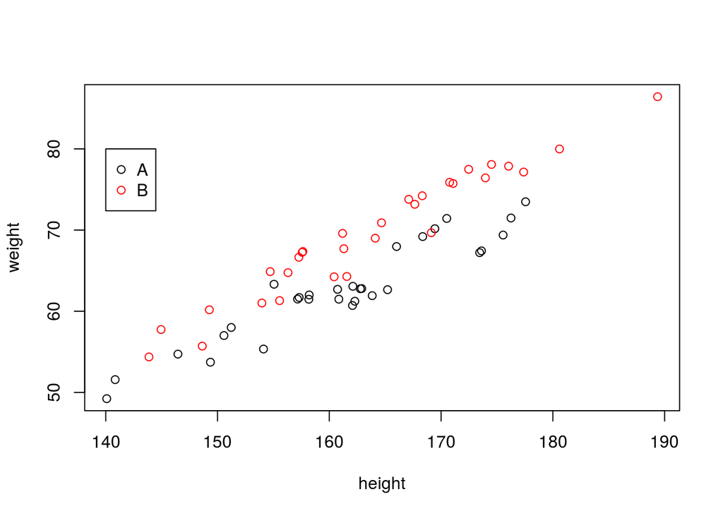

```r
plot(weight~height,data=df,col=as.numeric(group))
legend(140,80,legend=levels(group),col=c(1,2),pch=21)
```

## 1.4 Analysis

### 1.4.1 Description

```r
by(df[,-1],df$group,describe)
```

```
df$group: A
       vars  n mean  sd median trimmed mad min max range  skew kurtosis  se
height    1 30  161 9.9    162     161 9.9 140 178    37 -0.28    -0.60 1.8
weight    2 30   63 6.0     62      63 6.8  49  73    24 -0.21    -0.57 1.1
------------------------------------------------------------------------------------------
df$group: B
       vars  n mean   sd median trimmed  mad min max range  skew kurtosis  se
height    1 30  164 10.8    163     164 11.3 144 189    46  0.16    -0.53 2.0
weight    2 30   69  7.8     69      70  8.5  54  86    32 -0.04    -0.75 1.4
```

```r
cor(weight,height,method="pearson")
```

```
     [,1]
[1,] 0.91
```

```r
cor(weight,height,method="spearman")
```

```
     [,1]
[1,] 0.88
```

```r
by(df[,-1],df$group,cor)
```

```
df$group: A
       height weight
height   1.00   0.95
weight   0.95   1.00
------------------------------------------------------------------------------------------
df$group: B
       height weight
height   1.00   0.97
weight   0.97   1.00
```

### 1.4.2 Fitting a linear model

We now fit a linear model to the data, of course again with `lm()`

```r
mod<-lm(weight~group*height,df)
mod
```

```
Call:
lm(formula = weight ~ group * height, data = df)

Coefficients:
  (Intercept)         groupB         height  groupB:height
      -30.329        -14.531          0.577          0.121
```

The output show the point estimates $\hat{\beta}$. For further information, we already know the `summary()` function.

```r
summary(mod)
```

```
Call:
lm(formula = weight ~ group * height, data = df)

Residuals:
   Min     1Q Median     3Q    Max
-3.649 -1.546  0.413  1.420  4.236

Coefficients:
              Estimate Std. Error t value Pr(>|t|)
(Intercept)   -30.3289     5.8828   -5.16  3.4e-06
groupB        -14.5310     8.0328   -1.81    0.076
height          0.5767     0.0365   15.82  < 2e-16
groupB:height   0.1214     0.0494    2.46    0.017

Residual standard error: 1.9 on 56 degrees of freedom
Multiple R-squared:  0.94,  Adjusted R-squared:  0.937
F-statistic:  292 on 3 and 56 DF,  p-value: <2e-16
```

Note that the term **residual standard error** is a misnomer with a long tradition, since *standard error* for an estimated parameter $\theta$ usually means $\sqrt{Var(\hat{\theta})}$. The correct term would be **residual standard deviation**.

The true beta values and the true sigma are

```r
betaEffects
```

```
[1] -36.475  -9.025   0.615   0.085
```

```r
sigma
```

```
[1] 2
```

Of course, in real life, you will not know the true values.

We can now add the model fit to the data:

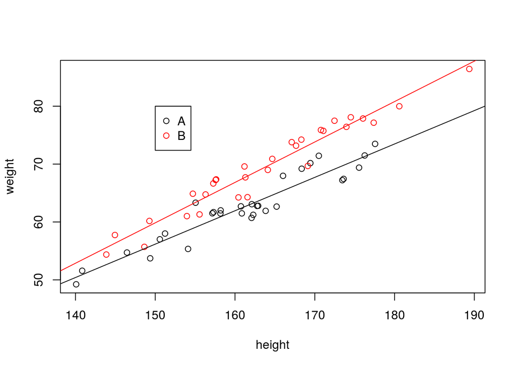

```r
plot(weight~height,data=df,col=as.numeric(group))
legend(150,80,legend=levels(group),col=c(1,2),pch=21)
abline(mod$coef[1],mod$coef[3],col=1)
abline(mod$coef[1]+mod$coef[2],mod$coef[3]+mod$coef[4],col=2)
```

Let us construct confidence intervals for the true effects.

```r
confint(mod,level=0.95)
```

```
                2.5 % 97.5 %
(Intercept)   -42.114 -18.54
groupB        -30.623   1.56
height          0.504   0.65
groupB:height   0.022   0.22
```

$\beta$ will be overlapped by a ($1-\alpha$)-CI with a “long-run-probability” of ($1-\alpha$).

If we want a enhanced output, we can use the `kable()` function:

```r
knitr::kable(cbind(summary(mod)$coef,confint(mod)),digits=3)
```

|  | Estimate | Std. Error | t value | Pr(>\|t\|) | 2.5 % | 97.5 % |
| --- | --- | --- | --- | --- | --- | --- |
| (Intercept) | -30.33 | 5.883 | -5.2 | 0.000 | -42.114 | -18.54 |
| groupB | -14.53 | 8.033 | -1.8 | 0.076 | -30.623 | 1.56 |
| height | 0.58 | 0.036 | 15.8 | 0.000 | 0.504 | 0.65 |
| groupB:height | 0.12 | 0.049 | 2.5 | 0.017 | 0.022 | 0.22 |

and for the `anova()` results

```r
knitr::kable(anova(mod),digits=3)
```

|  | Df | Sum Sq | Mean Sq | F value | Pr(>F) |
| --- | --- | --- | --- | --- | --- |
| group | 1 | 708 | 708.0 | 188 | 0.000 |
| height | 1 | 2569 | 2569.4 | 683 | 0.000 |
| group:height | 1 | 23 | 22.7 | 6 | 0.017 |
| Residuals | 56 | 211 | 3.8 | NA | NA |

### 1.4.3 Interpretation

The estimated **increase in weight by unit change on height** is larger in group B than in group A, the **difference in slopes** is $\hat{\beta}=0.1214138$ (with 95% CI: 0.0224471, 0.2203805). We can reject the null model of no-interaction.

### 1.4.4 Principle of marginality

**Take care**: $F$-tests in R (`anova()` and `aov()`) are **sequential** (so-called Type I sum of squares), the order the terms enter the model does matter! The $t$-tests in `lm()` on the contrary are marginal (impact of the variables, given the presence of **all the other variables** in the model).

Note the difference between the summary output and the anova output. In the former, we see marginal tests, in the latter, we see – the correct – sequential tests. Sequential tests (also called Type I tests) respect the the principle of [**marginality**](https://en.wikipedia.org/wiki/Principle_of_marginality). As example, it makes no sense that a main effect is controlled for the interaction effect. **Do not interpret main effects in the presence of interaction effects!**

If we wanted to reproduce the senseless $p$-value for the group main effect in the summary output (0.0758265), we compare the interaction model with the same model without the main effect of group:

```r
modNoMainG<-lm(weight~height*group-group) #equals weight~height+height:group
anova(mod,modNoMainG)
```

```
Analysis of Variance Table

Model 1: weight ~ group * height
Model 2: weight ~ height * group - group
  Res.Df RSS Df Sum of Sq    F Pr(>F)
1     56 211
2     57 223 -1     -12.3 3.27  0.076
```

Marginal tests (often used in SPSS, so called Type III tests) are implemented also in the `Anova()` function of the `car` package, but **in general, you are more safe with sequential tests**.

```r
car::Anova(mod,type=3)
```

```
Anova Table (Type III tests)

Response: weight
             Sum Sq Df F value  Pr(>F)
(Intercept)     100  1   26.58 3.4e-06
group            12  1    3.27   0.076
height          942  1  250.22 < 2e-16
group:height     23  1    6.04   0.017
Residuals       211 56
```

### 1.4.5 Global $F$-test

The global $F$-test in the summary output tells us if the models explains anything at all, this can be reproduced by

```r
mod0<-lm(weight~1)
anova(mod0,mod)
```

```
Analysis of Variance Table

Model 1: weight ~ 1
Model 2: weight ~ group * height
  Res.Df  RSS Df Sum of Sq   F Pr(>F)
1     59 3511
2     56  211  3      3300 292 <2e-16
```

### 1.4.6 Residual analysis

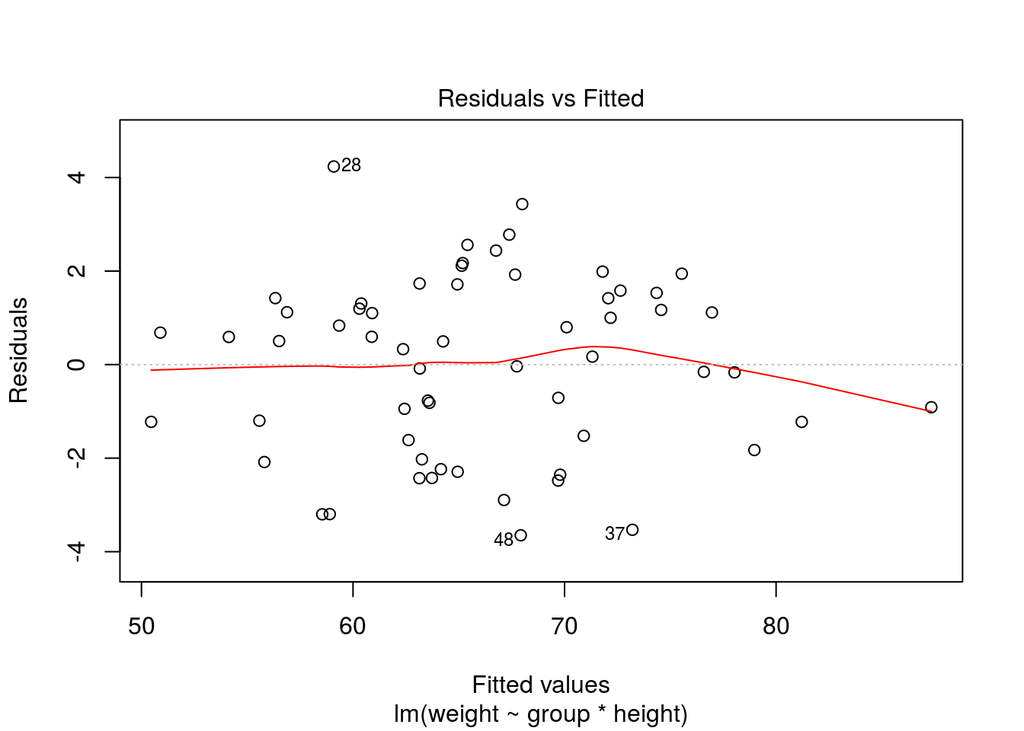

```r
plot(mod,which=1)
```

## 1.5 Prediction

At the end of the day, we also want to predict new observations from a fitted model. This is implemented in the `predict()` function. There are two kinds of predictions, mean predictions or individual predictions.

The difference between **confidence bound for the expected value** given predictor value versus **prediction bound for future observation** given predictor value is visualized in [shinyApp](https://rstudio-pubs.zhaw.ch/connect/#/apps/8/access).

Assume we want to predict new observations for different arbitrary combinations on group and height:

```r
new<-data.frame(group=c("A","B","A"),height=c(170,180,190))
new
```

```
  group height
1     A    170
2     B    180
3     A    190
```

- Uncertainty for new observation $Y_{new}\mid X_{new}=x_{new}$

```r
pred<-predict(mod,newdata=new,interval="prediction")
cbind(new,pred)
```

```
  group height fit lwr upr
1     A    170  68  64  72
2     B    180  81  77  85
3     A    190  79  75  84
```

- Uncertainty for the conditional mean $E(Y_{new}\mid X_{new}=x_{new})$

```r
pred2<-predict(mod,newdata=new,interval="confidence")
cbind(new,pred2)
```

```
  group height fit lwr upr
1     A    170  68  67  69
2     B    180  81  79  82
3     A    190  79  77  81
```

Let us draw confidence and prediction bounds for each possible length and for each group:

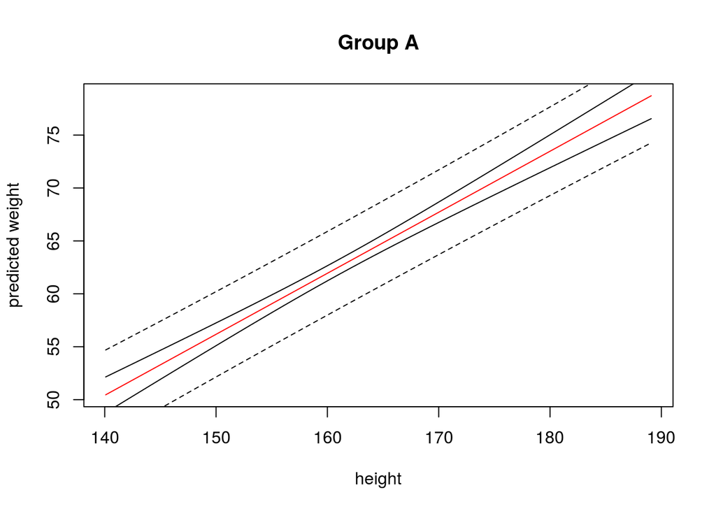

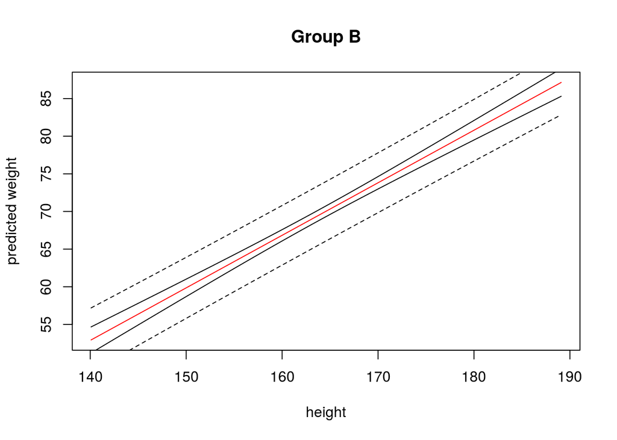

```r
pred.frame<-data.frame(group="A",height=seq(min(df$height),max(df$height)))
pc<-data.frame(predict(mod,newdata=pred.frame,interval="confidence"))
pp<-data.frame(predict(mod,newdata=pred.frame,interval="prediction"))
plot(pred.frame$height,pc[,1],col=2,type="l",xlab="height",ylab="predicted weight",main="Group A")
lines(pred.frame$height,pc[,2])
lines(pred.frame$height,pc[,3])
lines(pred.frame$height,pp[,2],lty=2)
lines(pred.frame$height,pp[,3],lty=2)
pred.frame<-data.frame(group="B",height=seq(min(df$height),max(df$height)))
pc<-data.frame(predict(mod,newdata=pred.frame,interval="confidence"))
pp<-data.frame(predict(mod,newdata=pred.frame,interval="prediction"))
plot(pred.frame$height,pc[,1],col=2,type="l",xlab="height",ylab="predicted weight",main="Group B")
lines(pred.frame$height,pc[,2])
lines(pred.frame$height,pc[,3])
lines(pred.frame$height,pp[,2],lty=2)
lines(pred.frame$height,pp[,3],lty=2)
```

Of course, predictions for a new observation (dashed lines) have more uncertainty (larger prediction bounds) than predictions of an expected value (solid lines, called confidence bounds).

**Uncertainty of predictions can be (very) large**. In statistics, it is crucial to quantify the corresponding uncertainty. We have seen in this section that we cannot only quantify uncertainty for estimates of parameters $\beta$, but also for future unobserved responses $\hat{Y}$!

As example, assume a study with running athletes to predict Maximal Heart Rate as a function of age with data.

```r
Age <- c(18,23,25,35,65,54,34,56,72,19,23,42,18,39,37)
HR <- c(202,186,187,180,156,169,174,172,153,199,193,174,198,183,178)
```

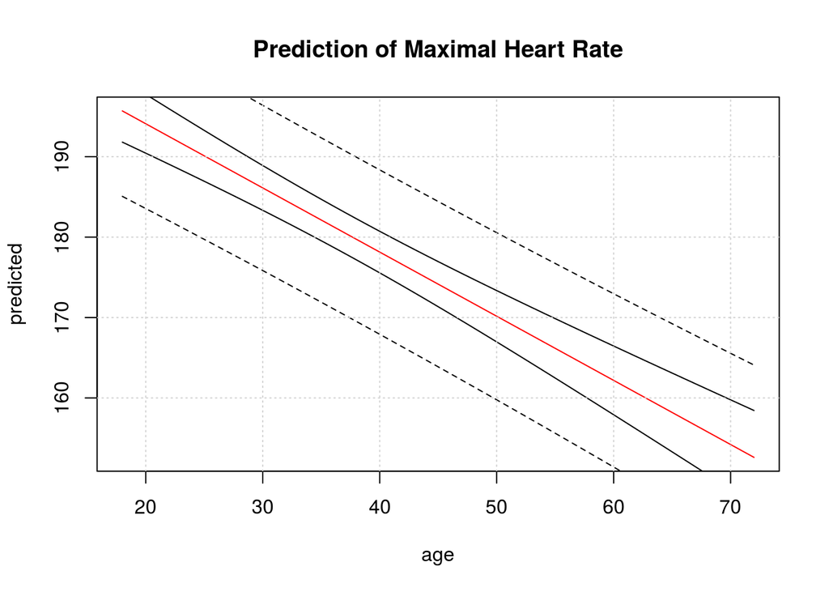

```r
modHR <- lm(HR~Age)
pred.frame<-data.frame(Age=18:72)
pp<-predict(modHR,interval="prediction",newdata=pred.frame)
pc<-predict(modHR,interval="confidence",newdata=pred.frame)
pred.age<-pred.frame$Age
plot(pred.age,pp[,1],lty=1,type="l",main="Prediction of Maximal Heart Rate",ylab="predicted",col=2,xlab="age")
lines(pred.age,pc[,2],lty=1)
lines(pred.age,pc[,3],lty=1)
lines(pred.age,pp[,2],lty=2)
lines(pred.age,pp[,3],lty=2)
grid()
```

We see that the uncertainty is high and that simple formulas (such as 220-age, etc.) do not work for most people.